# Assignment 3: Image Colourization [50 Pt]

### Part (vi) [2pt DISCUSSION]

There are two ways to implement the conditional GAN. The first is a standard conditional GAN for which the generator is a decoder with an input that is random noise with a conditional. The second is the pix2pix architecture where the generator is a UNet architecture with a greyscale image input.

Briefly describe the pros and cons of the two different approaches in regards to the image colourization task.

Limit your answer to no more than 100 words.

```python
'''
PROVIDE YOUR ANSWER BELOW

Standard cGAN (noise + condition)

 - Pros: Adds a “random knob” (noise), so the same grayscale photo can get multiple valid colorings—more creative.

 - Cons: Harder to train; can have weird colors or mode collapse. Without a reconstruction loss, colors can drift from the ground truth.

pix2pix (U-Net, grayscale → color)

 - Pros: Skip connections act like “coloring within the lines,” preserving edges and structure. It’s stable and sharp.

 - Cons: Usually one fixed coloring per input (low diversity), sometimes desaturated. It also needs paired and aligned training data.




'''
```

## Part 2 New Data [6 Pt]

### Part (i) [4pt RESULTS]

Download the grayscale horse images provided [here](https://github.com/Sabaae/Dataset/blob/main/grayimages.zip) and use your best model to perform image colourization on all the 302 images. Provide all your code, including any image processing that you need to perform.

Print out several grayscale images from the provided dataset along with their colourized versions by your best model.

Report the colourized images by your chosen model as a single compressed [NPZ](https://numpy.org/doc/stable/reference/generated/numpy.savez_compressed.html) file called 'colourized.npz', containing the numpy array of type `float32` with the shape `(302, 32, 32, 3)`.

For grading, Fréchet Inception Distance (FID) will be used on your colourized images to compare the original colour images and your colourized images. The assumption is that if the colourization process is successful, the distribution of features learned by the network should be similar between the two sets of images. The following links provide more details about how FID is used for evaluation [link1](https://machinelearningmastery.com/how-to-implement-the-frechet-inception-distance-fid-from-scratch/), [link2](https://wandb.ai/ayush-thakur/gan-evaluation/reports/How-to-Evaluate-GANs-using-Frechet-Inception-Distance-FID---Vmlldzo0MTAxOTI), [link3](https://generativeai.pub/image-colorization-bringing-black-and-white-to-life-b14d3e0db763).

```
File path: data/grayimages.zip
```

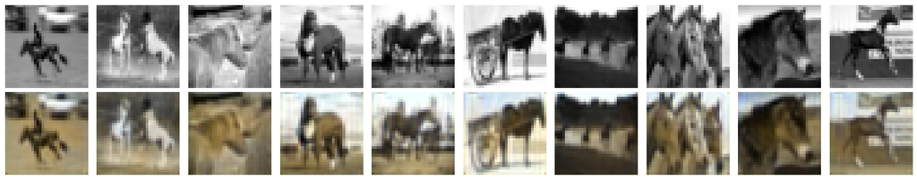

```
Saved colourized.npz (302, 32, 32, 3) float32
```

```python
# Colorize 302 grayscale horse images with your trained UNet and save colourized.npz
import os, zipfile, numpy as np, torch, matplotlib.pyplot as plt
from PIL import Image

# ---- your best model config (must match training) ----
args = {"gpu": True, "model": "UNet", "kernel": 3, "num_filters": 32, "experiment_name": "colourization_cnn"}

# ---- load trained UNet (state_dict saved by your train()) ----
def load_trained_unet(args):
    ckpt = os.path.join("outputs", args["experiment_name"], "regression_cnn.pt")
    dev  = "cuda" if (args["gpu"] and torch.cuda.is_available()) else "cpu"
    try:    G = UNet(args["kernel"], args["num_filters"])              # if UNet(kernel, num_filters)
    except TypeError:
            G = UNet(args["kernel"], args["num_filters"], 3, 1)        # fallback: (kernel, nf, num_colours, num_in_channels)
    G.load_state_dict(torch.load(ckpt, map_location=dev))
    return G.to(dev).eval(), dev

# ---- download & unzip grayscale set (uses your helper get_file) ----
RAW = "https://raw.githubusercontent.com/Sabaae/Dataset/main/grayimages.zip"
zip_path = get_file("grayimages.zip", origin=RAW, cache_dir="data")
root = "data/grayimages"; os.makedirs(root, exist_ok=True)
with zipfile.ZipFile(zip_path, "r") as z: z.extractall(root)

# collect exactly 302 images (handle nested /grayimages and duplicates)
scan_root = os.path.join(root, "grayimages") if os.path.isdir(os.path.join(root, "grayimages")) else root
all_paths = [os.path.join(dp,f) for dp,_,fs in os.walk(scan_root) for f in fs if f.lower().endswith((".png",".jpg",".jpeg"))]
uniq = {};
for p in all_paths:
    k = os.path.splitext(os.path.basename(p))[0]
    if k not in uniq: uniq[k] = p
paths = sorted(uniq.values())[:302]
assert len(paths) == 302, f"got {len(paths)}"

# ---- load model and run inference ----
G, dev = load_trained_unet(args)
outs = np.zeros((302,32,32,3), np.float32)
with torch.no_grad():
    for i, p in enumerate(paths):
        g = Image.open(p).convert("L").resize((32,32), Image.BILINEAR)
        x = torch.from_numpy(np.array(g, np.float32)/255.0)[None,None].to(dev)   # [1,1,32,32]
        y = G(x).clamp(0,1).cpu().numpy()[0].transpose(1,2,0).astype(np.float32) # (32,32,3)
        outs[i] = y

# ---- visualize first 10 pairs ----
plt.figure(figsize=(18,3.6))
for i in range(10):
    g = np.array(Image.open(paths[i]).convert("L").resize((32,32), Image.BILINEAR), np.float32)/255.0
    ax=plt.subplot(2,10,i+1); ax.imshow(g, cmap="gray"); ax.axis("off")
    ax=plt.subplot(2,10,10+i+1); ax.imshow(outs[i]); ax.axis("off")
plt.tight_layout(); plt.show()

# ---- save NPZ for grading ----
np.savez_compressed("colourized.npz", outs)
print("Saved colourized.npz", outs.shape, outs.dtype)
```